# Smoking Paper - Appendix A

Genus level

# Data preparation

```r
> # from Bioconductor (install by running: BiocManager::install("x") | x = name of the package)
> # BiocManager::install(c("DESeq2", "phyloseq", "microbiome"))
>
>
> packages_github_links <- list(
+   speedyseq = "mikemc/speedyseq",
+   gautils = "g-antonello/gautils",
+   LinDA = "zhouhj1994/LinDA"
+ )
> missing_github_pkgs <- !sapply(names(packages_github_links), function(pkg) pkg %in% rownames(installed.packages()))
> missing_github_pkgs <- names(missing_github_pkgs[missing_github_pkgs])
>
> if(length(missing_github_pkgs) > 0){
+ sapply(missing_github_pkgs, function(pkg) devtools::install_github(packages_github_links[[pkg]]))
+ }
>
> library(gautils)
> library(magrittr) # imported separately from tidyverse to also import '%<>%'
> library(ggpubr)
> library(kableExtra)
>
>
> # graphics packages
> # library(ggpubr)
> # library(magrittr)
> # # my functions
> # source("my_personal_functions.R")
> #
> #
> # library(speedyseq)
> theme_set(theme_light())
>
>
> chrismb_phy <- readRDS("/shared/statgen/microbiome/CHRISMB/processed_data/microbiome_tables/phyloseq_built.Rds")
>
>
> threshold_prevalence <- 0.01
> threshold_detection <- 10
```

## Download CHRIS data

These are based on data retrieval from the `chrisData` internal R package curated by J. Rainer. Variable selection is done via consulting the codebook.

```r
> chrismb_phy <- readRDS("/shared/statgen/microbiome/CHRISMB/processed_data/microbiome_tables/phyloseq_built.Rds")
>
> library(chrisData)
>
> possible_data_files <- chrisDataFile()
>
> selected_data_files <- c(
+     "general_information",
+     "household",
+     "clinical_traits",
+     "interview",
+     "labdata",
+     "substudies",
+     "drugs_summary"
+   )
>
> data_selected.list <- sapply(selected_data_files, function(x) chrisData(paste0(x, ".txt.gz")), USE.NAMES = T)
>
> data_selected.joined.df <- purrr::reduce(data_selected.list, full_join, by = "AID")
> data_selected.joined.df <- data_selected.joined.df[match(chrismb_phy@sam_data$AID, data_selected.joined.df$AID),]
>
> # Columns with all NAs must be necessarily removed
> all_NAs <- apply(data_selected.joined.df, 2, function(x) all(is.na(x)))
> data_selected.joined.df <- data_selected.joined.df[, !all_NAs]
>
> # Columns of class "chron" are problematic, they must be removed to be able to work with phyloseq and metadata data.frame back and forth
> data_selected.joined_NODates.df <- select(data_selected.joined.df, -contains(c("x0bp08", "x0bc03", "x0bc06")))
>
> rm(data_selected.list)
>
> chrismb_phy <- phy_add_metadata_variables(chrismb_phy, df = data_selected.joined_NODates.df, by = "AID")
>
>
> levels(chrismb_phy@sam_data$x0oh01) <- c("0", "1-9", "10-19", "20+")
> levels(chrismb_phy@sam_data$x0sm51) <- c("Never", "Former", "Current (R)", "Current (NR)")
> chrismb_phy@sam_data$x0an03a %<>% as.numeric()
>
> chrismb_phy@sam_data$x0_ager_cat <- cut(chrismb_phy@sam_data$x0_ager, breaks = c(18, 31, 41, 51, 61, 71, max(chrismb_phy@sam_data$x0_ager)+1), include.lowest = TRUE, labels = c("18-30", "31-40", "41-50", "51-60", "61-70", "71+"))
>
> # create some househod (hid) info
> chrismb_phy <- relocate_sample_data(chrismb_phy, x0_ager_cat, .after = x0_ager) %>%
+   mutate_sample_data(
+     hid = paste0("h", hid),
+     hid_size_chrismb = add_N_to_catVar(hid) %>% as.character() %>% gsub("h.*\\ ", "", .) %>% parse_number(),
+   smoking_exposure_ga =
+     case_when(
+       grepl("Current", as.character(x0sm51)) ~ "Current",
+       TRUE ~ as.character(x0sm51)
+       ) %>%
+     factor(levels = c("Never", "Former", "Current"))
+   ) %>%
+   relocate_sample_data(smoking_exposure_ga, .before = x0sm51)
```

## Smoking variables generation

### Bin smoking intensity (g/day)

```r
> ###############################
> ## bin daily tobacco smoked
> ###############################
>
> chrismb_phy %<>%
+   mutate_sample_data(
+     ### tobacco g per day (bin 5 by 5)
+     x0sm61_bin5cat = case_when(smoking_exposure_ga == "Current" & !is.na(x0sm61) ~ cut(
+       x0sm61,
+       breaks = c(0, 1, 2, seq(5, 30, 5), 61),
+       include.lowest = TRUE
+     )),
+   ### tobacco g per day (bin 5 by 5, semi-continuous, using upper limit of the range as integer)
+   x0sm61_bin5cont = case_when(smoking_exposure_ga == "Current" & !is.na(x0sm61) ~ cut(
+       x0sm61,
+       breaks = c(0, 1, 2, seq(5, 30, 5), 60),
+       labels = c(1, 2, seq(5, 30, 5), 60),
+       include.lowest = TRUE
+     )) %>% as.character() %>% as.numeric(),
+
+     ### tobacco g per day (bin 2 by 2)
+     x0sm61_bin2cat = case_when(smoking_exposure_ga == "Current" & !is.na(x0sm61) ~ cut(
+       x0sm61,
+       breaks = c(0, 1, seq(2, 30, 2), 60),
+       include.lowest = TRUE
+     )),
+
+   ### tobacco g per day (bin 2 by 2, semi-continuous, using upper limit of the range as integer)
+   x0sm61_bin2cont = case_when(smoking_exposure_ga == "Current" & !is.na(x0sm61) ~ cut(
+       x0sm61,
+       breaks = c(0, 1, seq(2, 30, 2), 60),
+       labels = c(1, seq(2, 30, 2), 60),
+       include.lowest = TRUE
+     )
+     ) %>% as.character() %>% as.numeric()
+   )
```

### Bin Years since quitting

```r
> # x0sm40 = age when people quit or reduce
> # x0_ager = age rounded to closest integer
>
> max_value <- max(chrismb_phy@sam_data$x0_ager - chrismb_phy@sam_data$x0sm40, na.rm = T)
>
> chrismb_phy %<>%
+   mutate_sample_data(
+     years_since_quitting_or_reducing = x0_ager - x0sm40,
+
+     years_since_quitting_binned = case_when(
+       smoking_exposure_ga == "Former" & !is.na(years_since_quitting_or_reducing) ~ cut(years_since_quitting_or_reducing,
+                                             breaks = c(0,1,3,5,10,max_value),
+       include.lowest = TRUE
+     )
+   )
+ )
>
> rm(max_value)
```

### Ultimate smoking variable for plots: “smoking_detailed”

```r
> chrismb_phy %<>%
+   mutate_sample_data(
+     smoking_detailed = case_when(
+       smoking_exposure_ga == "Never" ~ "Never",
+
+       smoking_exposure_ga == "Former" ~ paste(smoking_exposure_ga,
+                                                years_since_quitting_binned,
+                                                "y"),
+       smoking_exposure_ga == "Current" ~ paste(smoking_exposure_ga,
+                                                x0sm61_bin5cat,
+                                                "g"),
+       TRUE ~ "Other"
+     ),
+     smoking_detailed.Extra = case_when(
+       smoking_exposure_ga == "Never" ~ "Never",
+
+       smoking_exposure_ga == "Former" ~ paste(smoking_exposure_ga,
+                                                years_since_quitting_or_reducing,
+                                                "y"),
+       smoking_exposure_ga == "Current" ~ paste(smoking_exposure_ga,
+                                                x0sm61,
+                                                "g"),
+       TRUE ~ "Other"
+     )
+
+   )
>
>
>
> nice_order_current <- sort(grep("Current", unique(chrismb_phy@sam_data$smoking_detailed), value = TRUE))[c(9,1,4,8,2,3,5,6,7,10)] %>% rev()
>
> nice_order_former <- sort(grep("Former", unique(chrismb_phy@sam_data$smoking_detailed), value = TRUE))[c(5,1,3,4,2,6)]
>
> final_levels <- c(nice_order_current,nice_order_former, "Never")
>
>
> # SMOKING DETAILED 1 - make ordered factor, useful for plotting
> chrismb_phy@sam_data$smoking_detailed <- factor(chrismb_phy@sam_data$smoking_detailed, levels = final_levels)
```

## Available Samples for statistical analysis

```r
> excluded_samples_upon_request <- readLines("/home/gantonello/CHRISMB/participants lists each study/withdrawnConsents_AIDs.txt")
>
> chrismb_phy_core <- core(chrismb_phy, detection = threshold_detection, prevalence = threshold_prevalence)
>
> phy_Q1 <- chrismb_phy_core %>%
+   filter_sample_data(!(AID %in% excluded_samples_upon_request),
+                      !is.na(x0oh01),
+                      !is.na(x0_ager),
+                      !is.na(x0_sex),
+                      !is.na(x0sm51),
+                      #x0bc10 != 1, # people who smoked were reported as 1, NAs are treated as non-smoking
+                      x0dd51 == "No")
>
> phy_Q1
```

```
phyloseq-class experiment-level object
otu_table()   OTU Table:          [ 622 taxa and 1601 samples ]:
sample_data() Sample Data:        [ 1601 samples by 1505 sample variables ]:
tax_table()   Taxonomy Table:     [ 622 taxa by 8 taxonomic ranks ]:
phy_tree()    Phylogenetic Tree:  [ 622 tips and 621 internal nodes ]:
refseq()      DNAStringSet:       [ 622 reference sequences ]
taxa are rows
```

```r
> phy_Q1_genus <- phy_tax_glom(phy_Q1, "Genus")
>
>
> phy_Q1_meta <- meta(phy_Q1)
```

## Generate directories to save data and figures

# Supplementary Figures

## Figure A1 - Differential Abundant genera in comparable literature

```r
> # load significant genera found in Figure 1 and average the effect sizes, then get the sign (-1, +1)
> diff_abundant_genera_CHRISMB <- readRDS("../Main/results/Figure1/DiffAbundGenera/significant_genera_Consensus-and-log2FC.RDS") %>%
+   filter(taxon %in% readRDS("../Main/results/Figure1/DiffAbundGenera/significant_genera_consensus.RDS")) %>%
+   column_to_rownames("taxon") %>%
+   rowMeans(na.rm = T) %>%
+   as.data.frame() %>%
+   rownames_to_column("Genus") %>%
+   set_names(c("Genus", "CHRISMB")) %>%
+   mutate(CHRISMB = sign(CHRISMB))
>
> # load table of genera found in the literature
> excel_map <- read_tsv("appendix-input-data/diff_abund_genera_matrix_for_plots.tsv") %>%
+   full_join(diff_abundant_genera_CHRISMB, by = "Genus") %>%
+   column_to_rownames("Genus") %>%
+   as.matrix()
>
> excel_map[is.na(excel_map)] <- 0
```

```r
> excel_map_no_rare_genera <- excel_map[rowSums(abs(excel_map)) >= 3,]
>
> clust_cols <- hclust(dist(t(
+   excel_map_no_rare_genera
+ )))
> columns_ordered <- clust_cols$labels[clust_cols$order]
>
> clust_rows <- hclust(dist(excel_map_no_rare_genera))
> rows_ordered <- clust_rows$labels[clust_rows$order] %>% rev()
>
> heatmap_ggplot_common <- reshape2::melt(excel_map_no_rare_genera)  %>%
+   mutate(Var1 = factor(Var1, levels = rows_ordered),
+          Var2 = factor(Var2, levels = columns_ordered)) %>%
+   ggplot(aes(x = Var2, y = Var1, fill = factor(value)))+
+   geom_tile(color="darkgray")+
+   scale_fill_manual(name = "Differential Abundance",
+                     values = c("#2C54C7", "#FBF2BC", "#C72E2C"),
+                     labels = c("Decreased", "NA/NS", "Increased"))+
+   theme(
+     panel.border = element_blank(),
+     panel.grid.major = element_blank(),
+     panel.grid.minor = element_blank(),
+     axis.ticks = element_blank(),
+     axis.text.x = element_text(angle = -45, hjust = 0),
+     axis.text.y = element_text(hjust = 1)
+     )+
+   labs(
+     y = "Genus",
+     x = NULL
+   )
```

```r
> excel_map_genera_only1 <- excel_map[rowSums(abs(excel_map)) == 1,]
> excel_map_genera_only1 <- excel_map_genera_only1[, colSums(abs(excel_map_genera_only1)) > 0]
>
> clust_cols <- hclust(dist(t(
+   excel_map_genera_only1
+ )))
> columns_ordered <- clust_cols$labels[clust_cols$order]
>
> clust_rows <- hclust(dist(excel_map_genera_only1))
> rows_ordered <- clust_rows$labels[clust_rows$order] %>% rev()
>
> heatmap_ggplot_rare <- reshape2::melt(excel_map_genera_only1)  %>%
+   mutate(Var1 = factor(Var1, levels = rows_ordered),
+          Var2 = factor(Var2, levels = columns_ordered)) %>%
+   ggplot(aes(x = Var2, y = Var1, fill = factor(value)))+
+   geom_tile(color="darkgray")+
+   scale_fill_manual(name = "Differential Abundance Direction",
+                     values = c("#2C54C7", "#FBF2BC", "#C72E2C"),
+                     labels = c("Decreased", "NA/NS", "Increased"))+
+   theme(
+     panel.border = element_blank(),
+     panel.grid.major = element_blank(),
+     panel.grid.minor = element_blank(),
+     axis.ticks = element_blank(),
+     axis.text.x = element_text(angle = -45, hjust = 0),
+     axis.text.y = element_text(hjust = 1)
+     )+
+   labs(
+     y = "Genus",
+     x = NULL
+   )
```

**Figure A1. Heatmap of differentially abundant genera in smokers compared to non-smokers both in the literature and in the current study (CHRISMB).** Genera were manually annotated based on publications with comparable setup: cross-sectional, on a healthy population, and 16S amplicon microbiota data. The red color means increased abundance in smokers, the blue color means decreased abundance in smokers. The yellow color means not significant (NS) or not mentioned (NA) in the text nor in the supplementary materials. **(A)** Commonly reported genera (present in at least 3 studies). **(B)** Rarely reported genera (present in only one study).

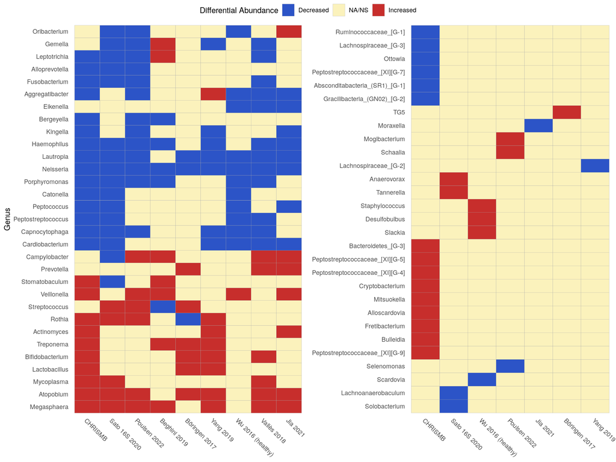

```r
> A1_plot <- ggarrange(heatmap_ggplot_common, heatmap_ggplot_rare+ labs(y = NULL), common.legend = T)
>
> ggsave(plot = A1_plot,
+        filename = "appendix_results/A1/A1_heatmap_diff_abund.genera.png",
+        height = 9,
+        width = 12,
+        dpi = 300)
>
> ggarrange(heatmap_ggplot_common, heatmap_ggplot_rare+ labs(y = NULL), common.legend = T)
```